# Using available data function

# Welcome to the Climate Future Toolbox’s Available Data function

This vignette provides a walk-through of a common use case of the Available Data function and the cft package: understanding climate futures for a region of interest. We’ll use Hot Springs National Park, located in Arkansas, USA and Yellowstone National Park, located in Wyoming, USA, as case studies.

Note that the available_data function is best used for downloading MACA climate model data for several climate variables from several climate models for any number of emission scenarios over a relatively small spatial region and over a relatively short time period. If you would like to download MACA climate model data for several climate variables from several climate models and any number of emission scenarios in their entirety for a single lat/long location, you should use the single_point_firehose function in the cft pacakge. A vignette on how to use the firehose function in the cft package is available at https://github.com/earthlab/cft/blob/main/vignettes/firehose.md.

### What you’ll learn

This vignette will show you how to:

- Access climate data for a spatial region of interest
- Produce a `data.frame` containing climate data
- Visualize historical and future data
- Generate and analyze new climate variables

### What you’ll need

To get the most out of this vignette, we assume you have:

- At least 500 MB of disk space
- Some familiarity with ggplot2
- Some familiarity with dplyr (e.g., [`filter()`](https://www.rdocumentation.org/packages/dplyr/versions/0.7.8/topics/filter), [`group_by()`](https://www.rdocumentation.org/packages/dplyr/versions/0.7.8/topics/group_by), and [`summarise()`](https://www.rdocumentation.org/packages/dplyr/versions/0.7.8/topics/summarise))

## About the data

Global Circulation Models (GCMs) provide estimates of historical and future climate conditions. The complexity of the climate system has lead to a large number GCMs and it is common practice to examine outputs from many different models, treating each as one plausible future.

Most GCMs are spatially coarse (often 1 degree), but downscaling provides finer scale estimates. The cft package uses one downscaled climate model called MACA (Multivariate Adaptive Climate Analog) Version 2 ([details here](http://www.climatologylab.org/maca.html)).

## Attach cft and check the list of available functions

```r
library(cft)
ls(pos="package:cft")
```

```
## [1] "available_data"        "single_point_firehose"
```

# Use read-only mode to find available data without initiating a full download.

```r
inputs <- cft::available_data()
```

```
## Trying to connect to the USGS.gov API
```

```
## not a file:
## ' https://cida.usgs.gov/thredds/dodsC/macav2metdata_daily_future '
##
## ... attempting remote connection
```

```
## Connection succeeded.
```

```
## Reading results
```

```
## Converting into an R data.table
```

## Look at the documentation for those functions

```r
?available_data
?single_point_firehose
```

Look at the variables, emission scenarios, and models for which data are available

```r
levels(as.factor(inputs$variable_names$Variable))
```

```
## [1] "Eastward Wind"                       "Maximum Relative Humidity"
## [3] "Maximum Temperature"                 "Minimum Relative Humidity"
## [5] "Minimum Temperature"                 "Northward Wind"
## [7] "Precipitation"                       "Specific Humidity"
## [9] "Surface Downswelling Shortwave Flux"
```

```r
levels(as.factor(inputs$variable_names$`Variable abbreviation`))
```

```
## [1] "huss"   "pr"     "rhsmax" "rhsmin" "rsds"   "tasmax" "tasmin" "uas"
## [9] "vas"
```

```r
levels(as.factor(inputs$variable_names$Scenario))
```

```
## [1] "RCP 4.5" "RCP 8.5"
```

```r
levels(as.factor(inputs$variable_names$`Scenario abbreviation`))
```

```
## [1] "rcp45" "rcp85"
```

```r
levels(as.factor(inputs$variable_names$Model))
```

```
##  [1] "Beijing Climate Center - Climate System Model 1.1"
##  [2] "Beijing Normal University - Earth System Model"
##  [3] "Canadian Earth System Model 2"
##  [4] "Centre National de Recherches Météorologiques - Climate Model 5"
##  [5] "Commonwealth Scientific and Industrial Research Organisation - Mk3.6.0"
##  [6] "Community Climate System Model 4"
##  [7] "Geophysical Fluid Dynamics Laboratory - Earth System Model 2 Generalized Ocean Layer Dynamics"
##  [8] "Geophysical Fluid Dynamics Laboratory - Earth System Model 2 Modular Ocean"
##  [9] "Hadley Global Environment Model 2 - Climate Chemistry 365 (day) "
## [10] "Hadley Global Environment Model 2 - Earth System 365 (day)"
## [11] "Institut Pierre Simon Laplace (IPSL) - Climate Model 5A - Low Resolution"
## [12] "Institut Pierre Simon Laplace (IPSL) - Climate Model 5A - Medium Resolution"
## [13] "Institut Pierre Simon Laplace (IPSL) - Climate Model 5B - Low Resolution"
## [14] "Institute of Numerical Mathematics Climate Model 4"
## [15] "Meteorological Research Institute - Coupled Global Climate Model 3"
## [16] "Model for Interdisciplinary Research On Climate - Earth System Model"
## [17] "Model for Interdisciplinary Research On Climate - Earth System Model - Chemistry"
## [18] "Model for Interdisciplinary Research On Climate 5"
## [19] "Norwegian Earth System Model 1 - Medium Resolution"
```

```r
levels(as.factor(inputs$variable_names$`Model abbreviation`))
```

```
##  [1] "bcc-csm1-1"     "bcc-csm1-1-m"   "BNU-ESM"        "CanESM2"
##  [5] "CCSM4"          "CNRM-CM5"       "CSIRO-Mk3-6-0"  "GFDL-ESM2G"
##  [9] "GFDL-ESM2M"     "HadGEM2-CC365"  "HadGEM2-ES365"  "inmcm4"
## [13] "IPSL-CM5A-LR"   "IPSL-CM5A-MR"   "IPSL-CM5B-LR"   "MIROC-ESM"
## [17] "MIROC-ESM-CHEM" "MIROC5"         "MRI-CGCM3"      "NorESM1-M"
```

This code downloads data for all models, all emission scenarios, and 5 climate variables. Notice that this is a large download request.

```r
library(magrittr)
library(dplyr)
input_variables <- inputs$variable_names %>%
  filter(Variable %in% c("Maximum Relative Humidity",
                       "Maximum Temperature",
                       "Minimum Relative Humidity",
                       "Minimum Temperature",
                       "Precipitation")) %>%
  filter(Scenario %in% c( "RCP 4.5", "RCP 8.5")) %>%
  filter(Model %in% c(
    "Beijing Climate Center - Climate System Model 1.1",
    "Beijing Normal University - Earth System Model",
    "Canadian Earth System Model 2",
  "Centre National de Recherches Météorologiques - Climate Model 5",
  "Commonwealth Scientific and Industrial Research Organisation - Mk3.6.0",
  "Community Climate System Model 4",
  "Geophysical Fluid Dynamics Laboratory - Earth System Model 2 Generalized Ocean Layer Dynamics",
  "Geophysical Fluid Dynamics Laboratory - Earth System Model 2 Modular Ocean",
  "Hadley Global Environment Model 2 - Climate Chemistry 365 (day) ",
 "Hadley Global Environment Model 2 - Earth System 365 (day)",
 "Institut Pierre Simon Laplace (IPSL) - Climate Model 5A - Low Resolution",
 "Institut Pierre Simon Laplace (IPSL) - Climate Model 5A - Medium Resolution",
 "Institut Pierre Simon Laplace (IPSL) - Climate Model 5B - Low Resolution",
 "Institute of Numerical Mathematics Climate Model 4",
 "Meteorological Research Institute - Coupled Global Climate Model 3",
 "Model for Interdisciplinary Research On Climate - Earth System Model",
 "Model for Interdisciplinary Research On Climate - Earth System Model - Chemistry",
 "Model for Interdisciplinary Research On Climate 5",
 "Norwegian Earth System Model 1 - Medium Resolution"  )) %>%

  pull("Available variable")
input_variables
```

```
##   [1] "pr_BNU-ESM_r1i1p1_rcp45"            "pr_BNU-ESM_r1i1p1_rcp85"
##   [3] "pr_CCSM4_r6i1p1_rcp45"              "pr_CCSM4_r6i1p1_rcp85"
##   [5] "pr_CNRM-CM5_r1i1p1_rcp45"           "pr_CNRM-CM5_r1i1p1_rcp85"
##   [7] "pr_CSIRO-Mk3-6-0_r1i1p1_rcp45"      "pr_CSIRO-Mk3-6-0_r1i1p1_rcp85"
##   [9] "pr_CanESM2_r1i1p1_rcp45"            "pr_CanESM2_r1i1p1_rcp85"
##  [11] "pr_GFDL-ESM2G_r1i1p1_rcp45"         "pr_GFDL-ESM2G_r1i1p1_rcp85"
##  [13] "pr_GFDL-ESM2M_r1i1p1_rcp45"         "pr_GFDL-ESM2M_r1i1p1_rcp85"
##  [15] "pr_HadGEM2-CC365_r1i1p1_rcp45"      "pr_HadGEM2-CC365_r1i1p1_rcp85"
##  [17] "pr_HadGEM2-ES365_r1i1p1_rcp45"      "pr_HadGEM2-ES365_r1i1p1_rcp85"
##  [19] "pr_IPSL-CM5A-LR_r1i1p1_rcp45"       "pr_IPSL-CM5A-LR_r1i1p1_rcp85"
##  [21] "pr_IPSL-CM5A-MR_r1i1p1_rcp45"       "pr_IPSL-CM5A-MR_r1i1p1_rcp85"
##  [23] "pr_IPSL-CM5B-LR_r1i1p1_rcp45"       "pr_IPSL-CM5B-LR_r1i1p1_rcp85"
##  [25] "pr_MIROC-ESM-CHEM_r1i1p1_rcp45"     "pr_MIROC-ESM-CHEM_r1i1p1_rcp85"
##  [27] "pr_MIROC-ESM_r1i1p1_rcp85"          "pr_MIROC-ESM_r1i1p1_rcp45"
##  [29] "pr_MIROC5_r1i1p1_rcp45"             "pr_MIROC5_r1i1p1_rcp85"
```

[output cut: 76 more lines]

# Establish area of interst (AOI) by bounding box

You will need to specify an appropriate area of interest for downloading spatial data. We utilize the functionality of open street map to make it fast and easy to download shapefiles for any area of interest. Here I am using the open street map (OSM) protocol to retrieve a shapefile for Hot Springs National Park. I choice this park because it is the smallest national park.

This chunk of code is first using the [getbb()](https://www.rdocumentation.org/packages/osmdata/versions/0.1.9/topics/getbb) function to retrieve a bounding box matching a plain language search request. That bounding box is then fed into the API call that retrieves the data and converts it into an r-specific spatial data format called sf.

OSM uses a ‘key’ and ‘value’ system for organizing requests. You may want to spend some time familiarizing yourself with the immense library of data you can access with this system. https://wiki.openstreetmap.org/wiki/Tags

```r
library(osmdata)
bb <- getbb("Hot Springs")
my_boundary <- opq(bb, timeout=300) %>%
  add_osm_feature(key = "boundary", value = "national_park") %>%
osmdata_sf()
my_boundary
```

```
## Object of class 'osmdata' with:
##                  $bbox : 34.4264361,-93.1290543,34.5594048,-92.9850972
##         $overpass_call : The call submitted to the overpass API
##                  $meta : metadata including timestamp and version numbers
##            $osm_points : 'sf' Simple Features Collection with 611 points
##             $osm_lines : NULL
##          $osm_polygons : 'sf' Simple Features Collection with 2 polygons
##        $osm_multilines : NULL
##     $osm_multipolygons : 'sf' Simple Features Collection with 1 multipolygons
```

Here you re-calibrate the bounding box relative to the actual shapefiles you downloaded. The bounding box above was pulled from the osm database, this bounding box is for the polygons you actually used. These two boxes may be the same or they may be different but the one derived from your downloaded shapefile is reproducible.

Notice that we specify osm_multipolygons instead of osm_polygons. This is a case-specific choice. When you download a shapefile from OSM, if will include a number of different spatial object types and you can choose several of those options to move forward. We chose multipolygons because they best matched our area of interest. Use the quick plot below to visualize your area of interest before continuing.

```r
library(osmdata)
library(sf)
boundaries <- my_boundary$osm_multipolygons
pulled_bb <- st_bbox(boundaries)
pulled_bb
```

```
##      xmin      ymin      xmax      ymax
## -93.11393  34.49884 -93.01857  34.55948
```

This quick map allows you to check that the polygon you downloaded matches your expectations.

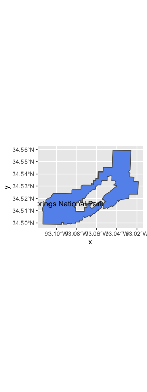

```r
library(ggplot2)
basemap <- ggplot(data = boundaries) +
  geom_sf(fill = "cornflowerblue") +
  suppressWarnings(geom_sf_text(aes(label = boundaries$name)))
basemap
```

# Download full time series from a single point

WARNING: TIME CONSUMING STEPS AHEAD

```r
library(osmdata)
library(sf)
library(tidync)
start_time <- Sys.time()
center_point <- st_centroid(boundaries) %>% st_bbox(center_point)
```

```
## Warning in st_centroid.sf(boundaries): st_centroid assumes attributes are
## constant over geometries of x
```

```r
times <- inputs$available_times
Pulled_data_single_space_single_timepoint <- inputs$src %>%
  hyper_filter(lat = lat <= c(center_point[4]+0.05) & lat >= c(center_point[2]-0.05)) %>%
  hyper_filter(lon = lon <= c(center_point[3]+0.05) & lon >= c(center_point[1]-0.05)) %>%
  hyper_filter(time = times$`Available times` ==  44558) %>%
  hyper_tibble(select_var = input_variables[1:38]) %>%
  st_as_sf(coords = c("lon", "lat"), crs = 4326, agr = "constant")
end_time <- Sys.time()
print(end_time - start_time)
```

```
## Time difference of 52.921 secs
```

```r
head(Pulled_data_single_space_single_timepoint)
```

```
## Simple feature collection with 6 features and 39 fields
## Attribute-geometry relationship: 39 constant, 0 aggregate, 0 identity
## Geometry type: POINT
## Dimension:     XY
## Bounding box:  xmin: -93.10602 ymin: 34.4796 xmax: -93.02267 ymax: 34.52126
## Geodetic CRS:  WGS 84
## # A tibble: 6 × 40
##   pr_BNU-ESM_r…¹ pr_BN…² pr_CC…³ pr_CC…⁴ pr_CN…⁵ pr_CN…⁶ pr_CS…⁷ pr_CS…⁸ pr_Ca…⁹
##            <dbl>   <dbl>   <dbl>   <dbl>   <dbl>   <dbl>   <dbl>   <dbl>   <dbl>
## 1           9.70       0    2.10       0       0       0       0       0    2.60
## 2           9.40       0    2.20       0       0       0       0       0    2.80
## 3           9.60       0    2.10       0       0       0       0       0    2.90
## 4           9.70       0    2.00       0       0       0       0       0    2.40
## 5           9.10       0    2.10       0       0       0       0       0    2.60
## 6           9.40       0    2.00       0       0       0       0       0    2.70
## # … with 31 more variables: pr_CanESM2_r1i1p1_rcp85 <dbl>,
## #   `pr_GFDL-ESM2G_r1i1p1_rcp45` <dbl>, `pr_GFDL-ESM2G_r1i1p1_rcp85` <dbl>,
## #   `pr_GFDL-ESM2M_r1i1p1_rcp45` <dbl>, `pr_GFDL-ESM2M_r1i1p1_rcp85` <dbl>,
## #   `pr_HadGEM2-CC365_r1i1p1_rcp45` <dbl>,
## #   `pr_HadGEM2-CC365_r1i1p1_rcp85` <dbl>,
## #   `pr_HadGEM2-ES365_r1i1p1_rcp45` <dbl>,
## #   `pr_HadGEM2-ES365_r1i1p1_rcp85` <dbl>, …
```

If you try to download a large quantity of data, you will likely get the following error: Error note: an error like this is likely a connection error. Try again. Sometime you need to restart your R session to clear memory. “curl error details: Error in R_nc4_open: NetCDF: I/O failure Error in ncdf4::nc_open(x$source$source[1]) : Error in nc_open trying to open file https://cida.usgs.gov/thredds/dodsC/macav2metdata_daily_future”

This error occurs when you try to download too much data using the available_data() function. If you are downloading a large quantity of data, you should use the firehose() function in the cft package instead of the available_data() function. Running the code in the following code chunk will likely produce this error.

NOTE: When you ask for a big download, that may exceed the API limit, the API asks you to confirm that you want to try. This will prompt a YES/NO question in your console that you need to answer if you want to continue. If you find this step taking a very long time, check that your console isn’t waiting for you to confirm that you want to try this request.

```r
library(osmdata)
library(sf)
library(tidync)
start_time <- Sys.time()
center_point <- st_centroid(boundaries) %>% st_bbox(center_point)
Pulled_data_single_space_all_timepoints <- inputs$src %>%
  hyper_filter(lat = lat <= c(center_point[4]+0.05) & lat >= c(center_point[2]-0.05)) %>%
  hyper_filter(lon = lon <= c(center_point[3]+0.05) & lon >= c(center_point[1]-0.05)) %>%
  hyper_filter(time = times$`Available times` ==  44558) %>%
  hyper_tibble(select_var = input_variables) %>%
  st_as_sf(coords = c("lon", "lat"), crs = 4326, agr = "constant")
end_time <- Sys.time()
print(end_time - start_time)
head(Pulled_data_single_space_all_timepoints)
```

## Error when you try to download too much data at one time

This is where you will start seeing error returned from the API if you have requested too much data at one time.

Downloads from the API are limited to 500 MB per request. A request for a large area of interest combined with a long time series will return a cryptic runtime error informing you that your request was too large.

This error may look like this: “CURL Error: Transferred a partial file Error in Rsx_nc4_get_vara_int: NetCDF: DAP failure Var: pr_CCSM4_r6i1p1_rcp85 Ndims: 3 Start: 0,444,511 Count: 34333,2,3 Error in ncvar_get_inner(ncid2use, varid2use, nc$var[[li]]$missval, addOffset, : C function Rsx_nc4_get_var_int returned error”

The solution to this problem is to subset your requests to make them fit within the boundaries of the API. You can achieve this by balancing the size of your requested spatial extent and the length of your requested time period. For a small national park, it’s possible to pull the entire time series from the API but larger parks will require you to request shorter time window or stitch multiple time windows together.

## Filter time

Time is one of the easiest dimensions to filter along because the time data are organized by sequential number, so they are easy to cut up and reassemble without needing to reference outside tables. The request filter is sensitive to vector length, so we build in our filter indexes into the time dataframe to insure that they are all the same length.

```r
library(tibble)
# Year 2034
time_min <- 38716
time_max <- 73048
input_times <- inputs$available_times %>%
  add_column(index = 0) %>%
  add_column(first_half = 0) %>%
  add_column(second_half = 0)
input_times[which(inputs$available_times[,1] >= time_min & inputs$available_times[,1] <= time_max ),3] <- 1
med <- median(row_number(input_times[,3]))
input_times[which(as.numeric(row.names(input_times)) <= med),4] <- 1
input_times[which(as.numeric(row.names(input_times)) > med),5] <- 1
tail(input_times)
```

```
##       Available times      dates index first_half second_half
## 34328           73043 2099-12-26     1          0           1
## 34329           73044 2099-12-27     1          0           1
## 34330           73045 2099-12-28     1          0           1
## 34331           73046 2099-12-29     1          0           1
## 34332           73047 2099-12-30     1          0           1
## 34333           73048 2099-12-31     1          0           1
```

## Download full time series as a set of smaller downloads

When your data request is too big for a single API request, it will need to be cut it into smaller requests. You can use the new index columns we created in the time table above to cut our single request into two requests. This leaves you with two data tables instead of one. You can bind these two tables back together, but it is time consuming to do so because the two tables have to take turns writing themselves to a new third table that they can occupy together. This takes a lot of short term memory and errors out some machines. It will save you time and effort if you can avoid binding them back together.

```r
library(tidync)
Pulled_data_sub1 <- Pulled_data <- inputs$src %>%
  hyper_filter(lat = lat <= c(center_point[4]+0.05) & lat >= c(center_point[2]-0.05)) %>%
  hyper_filter(lon = lon <= c(center_point[3]+0.05) & lon >= c(center_point[1]-0.05)) %>%
  hyper_filter(time =  input_times[,4] == 1) %>%
  hyper_tibble(select_var = input_variables
    )
Pulled_data_sub2 <- Pulled_data <- inputs$src %>%
  hyper_filter(lat = lat <= c(center_point[4]+0.05) & lat >= c(center_point[2]-0.05)) %>%
  hyper_filter(lon = lon <= c(center_point[3]+0.05) & lon >= c(center_point[1]-0.05)) %>%
  hyper_filter(time =  input_times[,5] == 1) %>%
  hyper_tibble(select_var = input_variables
    )
tail(Pulled_data_sub1)
tail(Pulled_data_sub2)
```

# Expanding to include a large area of interest

In the previous examples, we pulled data from a single point in the center of a small national park. Now, we will show you how to download, analyze, and visualize these data over a large spatial extent.

First, we will redefine our area of interest to include all the national parks that touch Yellowstone National Park. OSM provides a bounding box just like we used above for Hot Springs, Arkansas. However, the bounding box provided by OSM for the national parks that touch Yellowstone National Park is larger than the official bounding box provided by the national parks service. In the following code, we start by obtaining the bounding box from OSM and then manually adjust the corners of that bounding box to match the official bounding box from the national parks service.

```r
library(osmdata)
library(sf)
bb <- getbb("yellowstone")
bb_manual <- bb
bb_manual[1,1] <- -111.15594815937659
bb_manual[1,2] <- -109.8305463801207
bb_manual[2,1] <- 44.12354048271325
bb_manual[2,2] <- 45.11911641599412
my_boundary_yellow <- opq(bb_manual, timeout=300) %>%
  add_osm_feature(key = "boundary", value = "national_park") %>%
osmdata_sf()
my_boundary_yellow
```

```
## Object of class 'osmdata' with:
##                  $bbox : 44.1235404827133,-111.155948159377,45.1191164159941,-109.830546380121
##         $overpass_call : The call submitted to the overpass API
##                  $meta : metadata including timestamp and version numbers
##            $osm_points : 'sf' Simple Features Collection with 3135 points
##             $osm_lines : 'sf' Simple Features Collection with 33 linestrings
##          $osm_polygons : 'sf' Simple Features Collection with 0 polygons
##        $osm_multilines : NULL
##     $osm_multipolygons : 'sf' Simple Features Collection with 2 multipolygons
```

```r
boundaries_large <- my_boundary_yellow$osm_multipolygons
pulled_bb_large <- st_bbox(boundaries_large)
pulled_bb_large
```

```
##       xmin       ymin       xmax       ymax
## -111.15599   44.04375 -109.82549   45.10896
```

Let’s do another quickplot to make sure our area of interest matches our expectations.

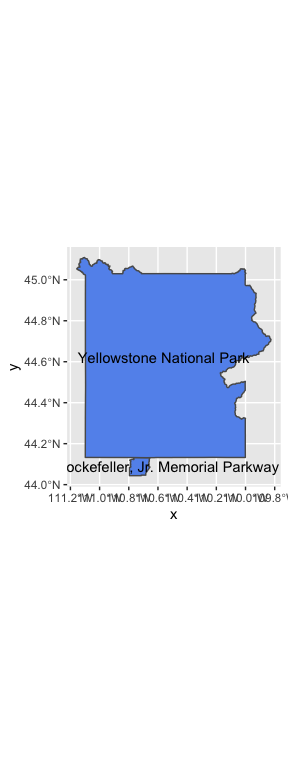

```r
library(ggplot2)
basemap <- ggplot(data = boundaries_large) +
  geom_sf(fill = "cornflowerblue") +
  suppressWarnings(geom_sf_text(aes(label = boundaries_large$name)))
basemap
```

## Large area with few variables

As your area of interest expands, you will need to cut you time and variable requests to accommodate more spatial points. Here we have cut our variables down to just “Precipitation”, our scenarios down to just “RCP 8.5”, and our models down to just “Model for Interdisciplinary Research On Climate 5”

```r
input_variables <- inputs$variable_names %>%
  filter(Variable %in% c( "Precipitation")) %>%
  filter(Scenario %in% c( "RCP 8.5")) %>%
  filter(Model %in% c(

 "Model for Interdisciplinary Research On Climate 5" )) %>%

  pull("Available variable")
input_variables
```

```
## [1] "pr_MIROC5_r1i1p1_rcp85"
```

# Download data by AOI, filtered times, and filtered variable list

```r
library(tidync)
Pulled_data_large_area_few_variables <- inputs$src %>%
  hyper_filter(lat = lat <= c(pulled_bb_large[4]+0.05) & lat >= c(pulled_bb_large[2]-0.05)) %>%
  hyper_filter(lon = lon <= c(pulled_bb_large[3]+0.05) & lon >= c(pulled_bb_large[1]-0.05)) %>%
  hyper_filter(time = input_times$`Available times` ==  73048) %>%
  hyper_tibble(select_var = input_variables
    ) %>%
  st_as_sf(coords = c("lon", "lat"), crs = 4326, agr = "constant")
head(Pulled_data_large_area_few_variables)
```

```
## Simple feature collection with 6 features and 2 fields
## Attribute-geometry relationship: 2 constant, 0 aggregate, 0 identity
## Geometry type: POINT
## Dimension:     XY
## Bounding box:  xmin: -111.1891 ymin: 44.02111 xmax: -110.9807 ymax: 44.02111
## Geodetic CRS:  WGS 84
## # A tibble: 6 × 3
##   pr_MIROC5_r1i1p1_rcp85  time             geometry
##                    <dbl> <dbl>          <POINT [°]>
## 1                  0.900 73048 (-111.1891 44.02111)
## 2                  1.00  73048 (-111.1474 44.02111)
## 3                  1.10  73048 (-111.1057 44.02111)
## 4                  1.00  73048 (-111.0641 44.02111)
## 5                  1.20  73048 (-111.0224 44.02111)
## 6                  1.50  73048 (-110.9807 44.02111)
```

```r
tail(Pulled_data_large_area_few_variables)
```

```
## Simple feature collection with 6 features and 2 fields
## Attribute-geometry relationship: 2 constant, 0 aggregate, 0 identity
## Geometry type: POINT
## Dimension:     XY
## Bounding box:  xmin: -110.0224 ymin: 45.14609 xmax: -109.8141 ymax: 45.14609
## Geodetic CRS:  WGS 84
## # A tibble: 6 × 3
##   pr_MIROC5_r1i1p1_rcp85  time             geometry
##                    <dbl> <dbl>          <POINT [°]>
## 1                   3.10 73048 (-110.0224 45.14609)
## 2                   4.30 73048 (-109.9807 45.14609)
## 3                   8.80 73048 (-109.9391 45.14609)
## 4                  11.0  73048 (-109.8974 45.14609)
## 5                  10.5  73048 (-109.8557 45.14609)
## 6                   9.70 73048 (-109.8141 45.14609)
```

### Time extent plot

```r
plot(Pulled_data_large_area_few_variables$time, Pulled_data_large_area_few_variables$`pr_MIROC5_r1i1p1_rcp85`)
```

[output not shown]

### Spatial extent plot

Check here to make sure you downloaded the proper spatial extent.

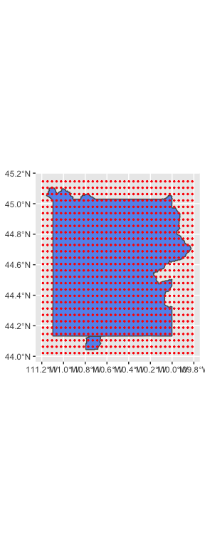

```r
library(ggplot2)
check_filter <- Pulled_data_large_area_few_variables %>% filter(time == min(Pulled_data_large_area_few_variables$time))
ggplot() +
  geom_sf(data = boundaries_large, fill = "cornflowerblue") +
 geom_sf(data = check_filter, color = "red", size=0.5) +
  coord_sf(crs = 4326)
```

## If you encounter an error suggesting that you are pulling too much data, you will need to stitch a few requests together to keep each call below the 500 MB limit.

```r
library(tidync)
Pulled_data_sub1 <- inputs$src %>%
  hyper_filter(lat = lat <= c(pulled_bb[4]+0.05) & lat >= c(pulled_bb[2]-0.05)) %>%
  hyper_filter(lon = lon <= c(pulled_bb[3]+0.05) & lon >= c(pulled_bb[1]-0.05)) %>%
  hyper_filter(time =  input_times[,4] == 1) %>%
  hyper_tibble(select_var = input_variables) %>%
  st_as_sf(coords = c("lon", "lat"), crs = 4326, agr = "constant")
Pulled_data_sub2 <- inputs$src %>%
  hyper_filter(lat = lat <= c(pulled_bb[4]+0.05) & lat >= c(pulled_bb[2]-0.05)) %>%
  hyper_filter(lon = lon <= c(pulled_bb[3]+0.05) & lon >= c(pulled_bb[1]-0.05)) %>%
  hyper_filter(time =  input_times[,5] == 1) %>%
  hyper_tibble(select_var = input_variables) %>%
  st_as_sf(coords = c("lon", "lat"), crs = 4326, agr = "constant")
tail(Pulled_data_sub1)
```

```
## Simple feature collection with 6 features and 2 fields
## Attribute-geometry relationship: 2 constant, 0 aggregate, 0 identity
## Geometry type: POINT
## Dimension:     XY
## Bounding box:  xmin: -93.14767 ymin: 34.56293 xmax: -92.98102 ymax: 34.60459
## Geodetic CRS:  WGS 84
## # A tibble: 6 × 3
##   pr_MIROC5_r1i1p1_rcp85  time             geometry
##                    <dbl> <dbl>          <POINT [°]>
## 1                      0 55882 (-92.98102 34.56293)
## 2                      0 55882 (-93.14767 34.60459)
## 3                      0 55882 (-93.10602 34.60459)
## 4                      0 55882 (-93.06433 34.60459)
## 5                      0 55882 (-93.02267 34.60459)
## 6                      0 55882 (-92.98102 34.60459)
```

```r
tail(Pulled_data_sub2)
```

```
## Simple feature collection with 6 features and 2 fields
## Attribute-geometry relationship: 2 constant, 0 aggregate, 0 identity
## Geometry type: POINT
## Dimension:     XY
## Bounding box:  xmin: -93.14767 ymin: 34.56293 xmax: -92.98102 ymax: 34.60459
## Geodetic CRS:  WGS 84
## # A tibble: 6 × 3
##   pr_MIROC5_r1i1p1_rcp85  time             geometry
##                    <dbl> <dbl>          <POINT [°]>
## 1                      0 73048 (-92.98102 34.56293)
## 2                      0 73048 (-93.14767 34.60459)
## 3                      0 73048 (-93.10602 34.60459)
## 4                      0 73048 (-93.06433 34.60459)
## 5                      0 73048 (-93.02267 34.60459)
## 6                      0 73048 (-92.98102 34.60459)
```

```r
Pulled_data_stitch <- bind_rows(Pulled_data_sub1, Pulled_data_sub2)
```

### Time extent plot

Check this plot to make sure you downloaded your entire time series.

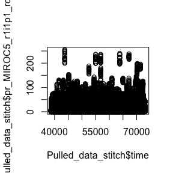

```r
plot(Pulled_data_stitch$time, Pulled_data_stitch$`pr_MIROC5_r1i1p1_rcp85`)
```

# Melt downloaded points into a raster before aggregation

```r
library(stars)
```

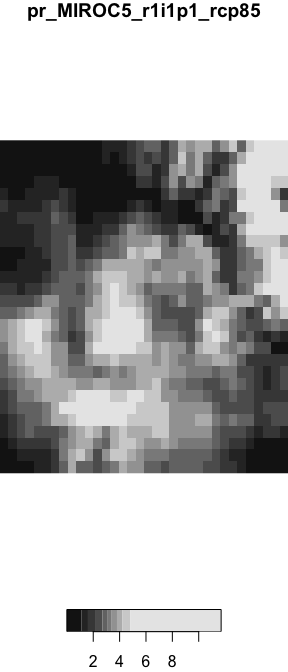

```r
rast <- st_rasterize(Pulled_data_large_area_few_variables)
plot(rast)
```

# Aggregate downloaded data to different spatial objects

## Aggregate to polygon (faster method)

In order to aggregate our downloaded data into a polygon, we will use the terra and tidyterra packages to convert the raster of downloaded points into a Spatial Raster.

```r
library(terra)
library(tidyterra)
data <- rast(rast)
```

We will now obtain the geometry of the boundary points for Yellowstone National Park and its adjacent national parks and convert them to a spatial object. We will then convert that spatial object into a Spatial Vector. Once we have a Spatial Vector of the boundary points for Yellowstone National Park and its adjacent national parks, we will extract data for those boundary points from the Spatial Raster and set xy=TRUE in order to obtain the lat/long coordinates of these points.

```r
library(terra)
points <- vect(as_Spatial(boundaries_large$geometry))
extracted <- terra::extract(data, points, xy=TRUE)
```

This code changes the name of the first column in the dataframe of extracted data at the boundary points for Yellowstone National Park and its adjacent national parks to ‘nn’.

```r
names(extracted)[1] <- "nn"
```

We will now convert the dataframe of extracted data at the boundary points for Yellowstone National Park and its adjacent national parks to a Spatial Vector using the lat/long coordinates of the points that we defined when we extracted the data from the Spatial Raster.

```r
boundary_data <- vect(extracted, geom=c("x", "y"), crs="")
boundary_data
```

```
##  class       : SpatVector
##  geometry    : points
##  dimensions  : 587, 3  (geometries, attributes)
##  extent      : -111.1057, -109.8556, 44.06277, 45.10443  (xmin, xmax, ymin, ymax)
##  coord. ref. :
##  names       :    nn pr_MIROC5_r1i1p1_rcp85_lyr.1 time_lyr.1
##  type        : <num>                        <num>      <num>
##  values      :     1                          4.1  7.305e+04
##                    1                          3.4  7.305e+04
##                    1                            3  7.305e+04
```

We will now use the plot and points functions from the terra package to produce a spatial plot of the downloaded precipitation data for the bounding box of Yellowstone National Park and to plot the data that were extracted along the boundary points of Yellowstone National Park and its adjacent national parks.

[figure not shown]

```r
plot(data$pr_MIROC5_r1i1p1_rcp85_lyr.1, main="Projected Humidity in 2040 in Yellowstone National Park")
points(boundary_data, col = 'blue', alpha=0.1)
```

# Filter the results from available_data() to specify which data to actually download.

The code in this section will walk through how to create time and variable filters in order to download data using the available_data function.

## Filter time

```r
library(tibble)
# Year 2034
time_min <- 72048
time_max <- 73048
input_times <- inputs$available_times %>% add_column(index = 0)
input_times[which(inputs$available_times[,1] > time_min & inputs$available_times[,1] < time_max ),3] <- 1
tail(input_times)
```

```
##       Available times      dates index
## 34328           73043 2099-12-26     1
## 34329           73044 2099-12-27     1
## 34330           73045 2099-12-28     1
## 34331           73046 2099-12-29     1
## 34332           73047 2099-12-30     1
## 34333           73048 2099-12-31     0
```

## Filter variable names

```r
input_variables <- inputs$variable_names %>%
  filter(Variable == "Precipitation") %>%
  filter(Model == c("Beijing Normal University - Earth System Model", "Hadley Global Environment Model 2 - Earth System 365 (day)")) %>%
  filter(Scenario == c( "RCP 8.5")) %>%
  pull("Available variable")
input_variables
```

```
## [1] "pr_HadGEM2-ES365_r1i1p1_rcp85"
```

# Establish area of interst (AOI) by bounding box

This code obtains the bounding box from Open Street Map (OSM) for the national parks adjacent to Yellowstone National Park and then manually updates the corners of the bounding box for this region to match the official bounding box from the National Parks Service. This is done because the bounding box obtained from OSM is larger than the official bounding box from the National Parks Service so this adjustment makes sure that the bounding box for our area of interest matches our desired area of interest.

```r
library(osmdata)
bb <- getbb("yellowstone")
bb_manual <- bb
bb_manual[1,1] <- -111.15594815937659
bb_manual[1,2] <- -109.8305463801207
bb_manual[2,1] <- 44.12354048271325
bb_manual[2,2] <- 45.11911641599412
my_boundary <- opq(bb_manual, timeout=300) %>%
  add_osm_feature(key = "boundary", value = "national_park") %>%
osmdata_sf()
my_boundary
```

```
## Object of class 'osmdata' with:
##                  $bbox : 44.1235404827133,-111.155948159377,45.1191164159941,-109.830546380121
##         $overpass_call : The call submitted to the overpass API
##                  $meta : metadata including timestamp and version numbers
##            $osm_points : 'sf' Simple Features Collection with 3135 points
##             $osm_lines : 'sf' Simple Features Collection with 33 linestrings
##          $osm_polygons : 'sf' Simple Features Collection with 0 polygons
##        $osm_multilines : NULL
##     $osm_multipolygons : 'sf' Simple Features Collection with 2 multipolygons
```

```r
library(osmdata)
library(sf)
boundaries <- my_boundary$osm_multipolygons
pulled_bb <- st_bbox(boundaries)
pulled_bb
```

```
##       xmin       ymin       xmax       ymax
## -111.15599   44.04375 -109.82549   45.10896
```

This code produces a map of the area of interest which can be used to ensure that the bounding box that was previously defined for the data matches our desired area of interest.

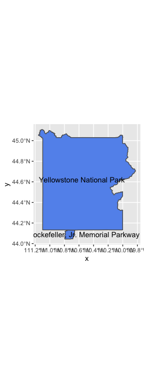

```r
library(ggplot2)
basemap <- ggplot(data = boundaries) +
  geom_sf(fill = "cornflowerblue") +
  suppressWarnings(geom_sf_text(aes(label = boundaries$name)))
basemap
```

# Download data by AOI, filtered times, and filtered variable list

```r
library(tidync)
Pulled_data <- inputs$src %>%
  hyper_filter(lat = lat <= c(pulled_bb[4]+0.05) & lat >= c(pulled_bb[2]-0.05)) %>%
  hyper_filter(lon = lon <= c(pulled_bb[3]+0.05) & lon >= c(pulled_bb[1]-0.05)) %>%
  hyper_filter(time =  input_times[,3] == 1) %>%
  hyper_tibble(select_var = input_variables
    ) %>%
  st_as_sf(coords = c("lon", "lat"), crs = 4326, agr = "constant")
head(Pulled_data)
```

```
## Simple feature collection with 6 features and 2 fields
## Attribute-geometry relationship: 2 constant, 0 aggregate, 0 identity
## Geometry type: POINT
## Dimension:     XY
## Bounding box:  xmin: -111.1891 ymin: 44.02111 xmax: -110.9807 ymax: 44.02111
## Geodetic CRS:  WGS 84
## # A tibble: 6 × 3
##   `pr_HadGEM2-ES365_r1i1p1_rcp85`  time             geometry
##                             <dbl> <dbl>          <POINT [°]>
## 1                            6.10 72049 (-111.1891 44.02111)
## 2                            7.30 72049 (-111.1474 44.02111)
## 3                            8.60 72049 (-111.1057 44.02111)
## 4                            9.40 72049 (-111.0641 44.02111)
## 5                            9.10 72049 (-111.0224 44.02111)
## 6                           10.3  72049 (-110.9807 44.02111)
```

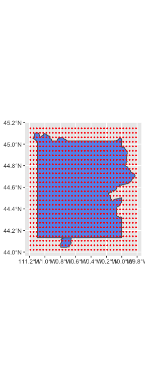

```r
library(ggplot2)
check_filter <- Pulled_data %>% filter(time == min(Pulled_data$time))
ggplot() +
  geom_sf(data = boundaries, fill = "cornflowerblue") +
 geom_sf(data = check_filter, color = "red", size=0.5) +
  coord_sf(crs = 4326)
```

# Climate Variables, Summaries, and Comparisons

### Computing new daily climate variables

First, we will download data for the RCP 8.5 emission scenario from the Model for Interdisciplinary Research on Climate - Earth System Model. This download will select maximum temperature, minimum temperature, eastward wind, and northward wind data within Yellowstone National Park at a single time point.

```r
library(tidync)
vars <- inputs$variable_names %>%
  filter(Variable %in% c("Maximum Temperature", "Minimum Temperature", "Eastward Wind", "Northward Wind")) %>%
  filter(Scenario %in% c("RCP 8.5")) %>%
  filter(Model %in% c("Model for Interdisciplinary Research On Climate - Earth System Model" )) %>%
  pull("Available variable")
dat <- inputs$src %>%
  hyper_filter(lat = lat <= c(pulled_bb_large[4]+0.05) & lat >= c(pulled_bb_large[2]-0.05)) %>%
  hyper_filter(lon = lon <= c(pulled_bb_large[3]+0.05) & lon >= c(pulled_bb_large[1]-0.05)) %>%
  hyper_filter(time = input_times$`Available times` ==  73048) %>%
  hyper_tibble(select_var = vars) %>%
  st_as_sf(coords = c("lon", "lat"), crs = 4326, agr = "constant")
head(dat)
```

```
## Simple feature collection with 6 features and 5 fields
## Attribute-geometry relationship: 5 constant, 0 aggregate, 0 identity
## Geometry type: POINT
## Dimension:     XY
## Bounding box:  xmin: -111.1891 ymin: 44.02111 xmax: -110.9807 ymax: 44.02111
## Geodetic CRS:  WGS 84
## # A tibble: 6 × 6
##   tasmax_MIROC-ESM_r1i…¹ tasmi…² uas_M…³ vas_M…⁴  time             geometry
##                    <dbl>   <dbl>   <dbl>   <dbl> <dbl>          <POINT [°]>
## 1                   273.    265.   0.700    2.90 73048 (-111.1891 44.02111)
## 2                   273.    264.   0.900    3.20 73048 (-111.1474 44.02111)
## 3                   273.    264.   1.00     2.90 73048 (-111.1057 44.02111)
## 4                   273.    264.   1.10     3.00 73048 (-111.0641 44.02111)
## 5                   273.    264.   1.20     3.10 73048 (-111.0224 44.02111)
## 6                   273.    263.   1.30     2.90 73048 (-110.9807 44.02111)
## # … with abbreviated variable names ¹`tasmax_MIROC-ESM_r1i1p1_rcp85`,
## #   ²`tasmin_MIROC-ESM_r1i1p1_rcp85`, ³`uas_MIROC-ESM_r1i1p1_rcp85`,
## #   ⁴`vas_MIROC-ESM_r1i1p1_rcp85`
```

The above code produces a list containing the data from the download. The following code converts the data from a list into a dataframe by first extracting each variable from the list and then producing a dataframe of those variables.

```r
tasmax <- dat$`tasmax_MIROC-ESM_r1i1p1_rcp85`
tasmin <- dat$`tasmin_MIROC-ESM_r1i1p1_rcp85`
uas <- dat$`uas_MIROC-ESM_r1i1p1_rcp85`
vas <- dat$`vas_MIROC-ESM_r1i1p1_rcp85`
time <- dat$time
df <- data.frame(time, tasmax, tasmin, uas, vas)
head(df)
```

```
##    time tasmax tasmin uas vas
## 1 73048  273.1  264.5 0.7 2.9
## 2 73048  273.2  264.4 0.9 3.2
## 3 73048  273.1  264.0 1.0 2.9
## 4 73048  273.0  263.8 1.1 3.0
## 5 73048  272.8  263.6 1.2 3.1
## 6 73048  272.5  263.3 1.3 2.9
```

Now that we have all of the climate parameters for our study region, we can compute functions of those variables. For example, it is common to compute the midpoint of the maximum and minimum daily temperature, which we can do using the `mutate` function:

```r
df <- df %>%
  mutate(tasmid = (tasmax + tasmin) / 2)
head(df)
```

```
##    time tasmax tasmin uas vas tasmid
## 1 73048  273.1  264.5 0.7 2.9 268.80
## 2 73048  273.2  264.4 0.9 3.2 268.80
## 3 73048  273.1  264.0 1.0 2.9 268.55
## 4 73048  273.0  263.8 1.1 3.0 268.40
## 5 73048  272.8  263.6 1.2 3.1 268.20
## 6 73048  272.5  263.3 1.3 2.9 267.90
```

Now we have a new column called `tasmid` that is the midpoint of the maximum and minumum daily temperature!

$\text{Wind speed} = \sqrt{v_{as}^2 + u_{as}^2}.$

In code:

```r
df <- df %>%
  mutate(wind_speed = sqrt(vas^2 + uas^2))
head(df)
```

```
##    time tasmax tasmin uas vas tasmid wind_speed
## 1 73048  273.1  264.5 0.7 2.9 268.80   2.983287
## 2 73048  273.2  264.4 0.9 3.2 268.80   3.324154
## 3 73048  273.1  264.0 1.0 2.9 268.55   3.067572
## 4 73048  273.0  263.8 1.1 3.0 268.40   3.195309
## 5 73048  272.8  263.6 1.2 3.1 268.20   3.324154
## 6 73048  272.5  263.3 1.3 2.9 267.90   3.178050
```

### Computing new climate variable summaries

```r
time_min <- inputs$available_times[which(inputs$available_times[,2] == '2019-12-31'),1]
time_max <- inputs$available_times[which(inputs$available_times[,2] == '2025-01-01'),1]
```

```r
input_times <- inputs$available_times
input_times$index <- rep(0, length(input_times$dates))
input_times[which(inputs$available_times[,1] > time_min & inputs$available_times[,1] < time_max ),3] <- 1
head(input_times)
```

```
##   Available times      dates index
## 1           38716 2006-01-01     0
## 2           38717 2006-01-02     0
## 3           38718 2006-01-03     0
## 4           38719 2006-01-04     0
## 5           38720 2006-01-05     0
## 6           38721 2006-01-06     0
```

We will now create a filter for the variables, emission scenarios, and models that we want to download.

```r
vars <- inputs$variable_names %>%
  filter(Variable %in% c("Minimum Temperature", "Maximum Temperature")) %>%
  filter(Scenario %in% c("RCP 8.5", "RCP 4.5")) %>%
  filter(Model %in% c("Model for Interdisciplinary Research On Climate - Earth System Model", "Norwegian Earth System Model 1 - Medium Resolution")) %>%
  pull("Available variable")
vars
```

```
## [1] "tasmax_MIROC-ESM_r1i1p1_rcp45" "tasmax_MIROC-ESM_r1i1p1_rcp85"
## [3] "tasmax_NorESM1-M_r1i1p1_rcp45" "tasmax_NorESM1-M_r1i1p1_rcp85"
## [5] "tasmin_MIROC-ESM_r1i1p1_rcp45" "tasmin_MIROC-ESM_r1i1p1_rcp85"
## [7] "tasmin_NorESM1-M_r1i1p1_rcp45" "tasmin_NorESM1-M_r1i1p1_rcp85"
```

This code uses both the time filter and the variable/model/emission scenario filter to download the desired data from the MACA climate model.

```r
library(tidync)
growing_data <- inputs$src %>%
  hyper_filter(lat = lat <= c(44.5+0.05) & lat >= c(44.5-0.05)) %>%
  hyper_filter(lon = lon <= c(-110.5+0.05) & lon >= c(-110.5-0.05)) %>%
  hyper_filter(time =  input_times[,3] == 1) %>%
  hyper_tibble(select_var = vars
    ) %>%
  st_as_sf(coords = c("lon", "lat"), crs = 4326, agr = "constant")
head(growing_data)
```

```
## Simple feature collection with 6 features and 9 fields
## Attribute-geometry relationship: 9 constant, 0 aggregate, 0 identity
## Geometry type: POINT
## Dimension:     XY
## Bounding box:  xmin: -110.5224 ymin: 44.47943 xmax: -110.4807 ymax: 44.5211
## Geodetic CRS:  WGS 84
## # A tibble: 6 × 10
##   tasmax_MIROC-E…¹ tasma…² tasma…³ tasma…⁴ tasmi…⁵ tasmi…⁶ tasmi…⁷ tasmi…⁸  time
##              <dbl>   <dbl>   <dbl>   <dbl>   <dbl>   <dbl>   <dbl>   <dbl> <dbl>
## 1             274.    273.    261.    262.    257.    260.    248.    252. 43829
## 2             274.    273.    261.    262.    257.    260.    248.    253. 43829
## 3             274.    273.    262.    262.    258.    261.    249.    253. 43829
## 4             274.    273.    261.    262.    257.    261.    249.    253. 43829
## 5             269.    274.    266.    261.    256.    263.    253.    250. 43830
## 6             269.    274.    265.    261.    257.    264.    253.    250. 43830
## # … with 1 more variable: geometry <POINT [°]>, and abbreviated variable names
## #   ¹`tasmax_MIROC-ESM_r1i1p1_rcp45`, ²`tasmax_MIROC-ESM_r1i1p1_rcp85`,
## #   ³`tasmax_NorESM1-M_r1i1p1_rcp45`, ⁴`tasmax_NorESM1-M_r1i1p1_rcp85`,
## #   ⁵`tasmin_MIROC-ESM_r1i1p1_rcp45`, ⁶`tasmin_MIROC-ESM_r1i1p1_rcp85`,
## #   ⁷`tasmin_NorESM1-M_r1i1p1_rcp45`, ⁸`tasmin_NorESM1-M_r1i1p1_rcp85`
```

We want to convert the downloaded data into a dataframe with columns for maximum temperature (tasmax), minimum temperature (tasmin), year, emission scenario (rcp), and model. In order to do so, we will start by determining how many values need to be in each of these vectors

```r
length(growing_data$time)
```

```
## [1] 7308
```

Create a vector of year values for the data in the dataframe

```r
year <- rep(c(rep(2020, 4*366), rep(2021, 4*365), rep(2022, 4*365), rep(2023, 4*365), rep(2024, 4*366)), 4)
length(year)
```

```
## [1] 29232
```

This code produces a vector of emission scenarios for the data in the dataframe

```r
rcp <- c(rep('rcp45', 7308), rep('rcp85', 7308), rep('rcp45', 7308), rep('rcp85', 7308))
length(rcp)
```

```
## [1] 29232
```

The following code produces a vector of model abbreviations for the data in the datafame

```r
model <- c(rep('MIROC-ESM', 2*7308), rep('NorESM1-M', 2*7308))
length(model)
```

```
## [1] 29232
```

We will now create a vector of maximum temperature data by combining the maximum temperature data from each emission scenario and model together. We then repeat this process to produces a vector of minimum temperature data by combining the minimum temperature data from each emission scenario and model.

```r
tasmax <- c(growing_data$`tasmax_MIROC-ESM_r1i1p1_rcp45`, growing_data$`tasmax_MIROC-ESM_r1i1p1_rcp85`, growing_data$`tasmax_NorESM1-M_r1i1p1_rcp45`, growing_data$`tasmax_NorESM1-M_r1i1p1_rcp85`)
tasmin <- c(growing_data$`tasmin_MIROC-ESM_r1i1p1_rcp45`, growing_data$`tasmin_MIROC-ESM_r1i1p1_rcp85`, growing_data$`tasmin_NorESM1-M_r1i1p1_rcp45`, growing_data$`tasmin_NorESM1-M_r1i1p1_rcp85`)
```

Now that we have created all of the vectors of data that we need, we will create a dataframe out of these vectors using the following code.

```r
df <- data.frame(tasmin, tasmax, year, rcp, model)
head(df)
```

```
##   tasmin tasmax year   rcp     model
## 1  256.8  274.2 2020 rcp45 MIROC-ESM
## 2  257.3  274.3 2020 rcp45 MIROC-ESM
## 3  257.7  274.0 2020 rcp45 MIROC-ESM
## 4  257.3  274.1 2020 rcp45 MIROC-ESM
## 5  256.1  268.5 2020 rcp45 MIROC-ESM
## 6  256.6  268.5 2020 rcp45 MIROC-ESM
```

In order to determine the length of the growing season, we need to find the midpoint temperature, meaning the average of the minimum and maximum temperature. The following code computes the midpoint temperature for each value in the dataframe and adds a column to our existing dataframe containing these values.

```r
df <- df %>%
  mutate(tasmid = (tasmax + tasmin) / 2)
head(df)
```

```
##   tasmin tasmax year   rcp     model tasmid
## 1  256.8  274.2 2020 rcp45 MIROC-ESM 265.50
## 2  257.3  274.3 2020 rcp45 MIROC-ESM 265.80
## 3  257.7  274.0 2020 rcp45 MIROC-ESM 265.85
## 4  257.3  274.1 2020 rcp45 MIROC-ESM 265.70
## 5  256.1  268.5 2020 rcp45 MIROC-ESM 262.30
## 6  256.6  268.5 2020 rcp45 MIROC-ESM 262.55
```

Sometimes, there are new climate variables that summarize daily data. For example, you may want to compute:

- Last Day of Frost (i.e., last day in spring when min. air temp. < 0 C)
- First Day of Frost (i.e., first day in fall when min. air temp. < 0 C)
- Number of days above or below some threshold (e.g., days with max. air temperature over 40 C, or days with > 1mm of precipitation)
- Growing season length (# days with air temperature > 0 C)

```r
#df <- df %>%
  #mutate(year = year(date))
```

```r
growing_seasons <- df %>%
  group_by(year) %>%
  mutate(season_length = sum(tasmid > 273.15))
```

```r
growing_seasons
```

[output not shown]

```r
library(ggplot2)
growing_seasons %>%
  ggplot(aes(x = year, y = season_length, color = rcp)) +
  geom_line(alpha = .3) +
  xlab("Year") +
  ylab("Growing season length (days)") +
  scale_color_manual(values = c("dodgerblue", "red")) +
  theme(legend.position = "none")
```

[output not shown]

## Comparing climate in two time periods

We now want to compare the climate in the middle of Yellowstone National Park between two time periods, 2020-2025 and 2025-2030. We will begin by creating a time filter using the following two code chunks. This time filter will select data between 2020 and 2030.

```r
time_min <- inputs$available_times[which(inputs$available_times[,2] == '2019-12-31'),1]
time_max <- inputs$available_times[which(inputs$available_times[,2] == '2031-01-01'),1]
```

```r
input_times <- inputs$available_times
input_times$index <- rep(0, length(input_times$dates))
input_times[which(inputs$available_times[,1] > time_min & inputs$available_times[,1] < time_max ),3] <- 1
tail(input_times)
```

```
##       Available times      dates index
## 34328           73043 2099-12-26     0
## 34329           73044 2099-12-27     0
## 34330           73045 2099-12-28     0
## 34331           73046 2099-12-29     0
## 34332           73047 2099-12-30     0
## 34333           73048 2099-12-31     0
```

We will now create a filter for the variables, emission scenarios, and models for which we want data from the MACA climate model. Here we are selecting precipitation and maximum temperature data for emission scenarios RCP 4.5 and RCP 8.5 from the Model for Interdisciplinary Research on Climate - Earth System Model and the medium resolution Norwegian Earth System Model 1.

```r
vars <- inputs$variable_names %>%
  filter(Variable %in% c("Precipitation", "Maximum Temperature")) %>%
  filter(Scenario %in% c("RCP 8.5", "RCP 4.5")) %>%
  filter(Model %in% c("Model for Interdisciplinary Research On Climate - Earth System Model", "Norwegian Earth System Model 1 - Medium Resolution")) %>%
  pull("Available variable")
vars
```

```
## [1] "pr_MIROC-ESM_r1i1p1_rcp85"     "pr_MIROC-ESM_r1i1p1_rcp45"
## [3] "pr_NorESM1-M_r1i1p1_rcp45"     "pr_NorESM1-M_r1i1p1_rcp85"
## [5] "tasmax_MIROC-ESM_r1i1p1_rcp45" "tasmax_MIROC-ESM_r1i1p1_rcp85"
## [7] "tasmax_NorESM1-M_r1i1p1_rcp45" "tasmax_NorESM1-M_r1i1p1_rcp85"
```

This code uses the variable, emission scenario, and climate model filter and the time filter that we defined previously to select and download data from the middle of Yellowstone National Park from the MACA climate model data.

```r
library(tidync)
climate_data <- inputs$src %>%
  hyper_filter(lat = lat <= c(44.5+0.05) & lat >= c(44.5-0.05)) %>%
  hyper_filter(lon = lon <= c(-110.5+0.05) & lon >= c(-110.5-0.05)) %>%
  hyper_filter(time =  input_times[,3] == 1) %>%
  hyper_tibble(select_var = vars
    ) %>%
  st_as_sf(coords = c("lon", "lat"), crs = 4326, agr = "constant")
head(climate_data)
```

```
## Simple feature collection with 6 features and 9 fields
## Attribute-geometry relationship: 9 constant, 0 aggregate, 0 identity
## Geometry type: POINT
## Dimension:     XY
## Bounding box:  xmin: -110.5224 ymin: 44.47943 xmax: -110.4807 ymax: 44.5211
## Geodetic CRS:  WGS 84
## # A tibble: 6 × 10
##   pr_MIROC-ESM_r…¹ pr_MI…² pr_No…³ pr_No…⁴ tasma…⁵ tasma…⁶ tasma…⁷ tasma…⁸  time
##              <dbl>   <dbl>   <dbl>   <dbl>   <dbl>   <dbl>   <dbl>   <dbl> <dbl>
## 1            6.60       NA   0        1.20    274.    273.    261.    262. 43829
## 2            5.90       NA   0        1.10    274.    273.    261.    262. 43829
## 3            6.80       NA   0        1.20    274.    273.    262.    262. 43829
## 4            6.00       NA   0        1.20    274.    273.    261.    262. 43829
## 5            0.400      NA   0.500    1.30    269.    274.    266.    261. 43830
## 6            0.400      NA   0.400    1.00    269.    274.    265.    261. 43830
## # … with 1 more variable: geometry <POINT [°]>, and abbreviated variable names
## #   ¹`pr_MIROC-ESM_r1i1p1_rcp85`, ²`pr_MIROC-ESM_r1i1p1_rcp45`,
## #   ³`pr_NorESM1-M_r1i1p1_rcp45`, ⁴`pr_NorESM1-M_r1i1p1_rcp85`,
## #   ⁵`tasmax_MIROC-ESM_r1i1p1_rcp45`, ⁶`tasmax_MIROC-ESM_r1i1p1_rcp85`,
## #   ⁷`tasmax_NorESM1-M_r1i1p1_rcp45`, ⁸`tasmax_NorESM1-M_r1i1p1_rcp85`
```

We now want to convert the data into a dataframe that has columns for the year, emission scenario (rcp), and climate model (model).

```r
length(climate_data$time)
```

```
## [1] 16072
```

The following code creates a vector of year values for the downloaded data.

```r
year <- rep(c(rep(2020, 4*366), rep(2021, 4*365), rep(2022, 4*365), rep(2023, 4*365), rep(2024, 4*366), rep(2025, 4*365), rep(2026, 4*365), rep(2027, 4*365), rep(2028, 4*366), rep(2029, 4*365), rep(2030, 4*365)), 4)
length(year)
```

```
## [1] 64288
```

This code produces a vector of rcp emission scenarios for the downloaded data.

```r
rcp <- c(rep('rcp45', 16072), rep('rcp85', 16072), rep('rcp45', 16072), rep('rcp85', 16072))
length(rcp)
```

```
## [1] 64288
```

The following code generates a vector of climate model abbreviations for the downloaded data.

```r
model <- c(rep('MIROC-ESM', 2*16072), rep('NorESM1-M', 2*16072))
length(model)
```

```
## [1] 64288
```

This code produces a vector of precipitation data, grouping first by model and then by emission scenario.

```r
pr <- c(climate_data$`pr_MIROC-ESM_r1i1p1_rcp45`, climate_data$`pr_MIROC-ESM_r1i1p1_rcp85`, climate_data$`pr_NorESM1-M_r1i1p1_rcp45`, climate_data$`pr_NorESM1-M_r1i1p1_rcp85`)
length(pr)
```

```
## [1] 64288
```

The following code produces a vector of maximum temperature data by first grouping by model and then grouping by emission scenario.

```r
tasmax <- c(climate_data$`tasmax_MIROC-ESM_r1i1p1_rcp45`, climate_data$`tasmax_MIROC-ESM_r1i1p1_rcp85`, climate_data$`tasmax_NorESM1-M_r1i1p1_rcp45`, climate_data$`tasmax_NorESM1-M_r1i1p1_rcp85`)
length(tasmax)
```

```
## [1] 64288
```

```r
#comps <- compare_periods(df,
                         #var1 = "pr",
                         #var2 = "tasmax",
                         #agg_fun = "mean",
                         #target_period = c(2025, 2030),
                         #reference_period = c(2020, 2024),
                         #scenarios = c("rcp45", "rcp85"))
```

```r
#glimpse(comps)
```

# Advanced Aggregation to Spatial Objects using Open Street Map

## Aggregate to River segment

This code obtains Open Street Map data for rivers in Yellowstone National Park and its adjacent parks and converts it to a spatial format.

```r
river <- opq(bb_manual, timeout=300) %>%
  add_osm_feature(key = "waterway", value = "river") %>%
  osmdata_sf()
river
```

```
## Object of class 'osmdata' with:
##                  $bbox : 44.1235404827133,-111.155948159377,45.1191164159941,-109.830546380121
##         $overpass_call : The call submitted to the overpass API
##                  $meta : metadata including timestamp and version numbers
##            $osm_points : 'sf' Simple Features Collection with 35817 points
##             $osm_lines : 'sf' Simple Features Collection with 552 linestrings
##          $osm_polygons : 'sf' Simple Features Collection with 0 polygons
##        $osm_multilines : 'sf' Simple Features Collection with 14 multilinestrings
##     $osm_multipolygons : NULL
```

The following code obtains a subset of the Open Street Map river geometry for Yellowstone National Park and its adjacent national parks and then converts it into a Spatial Vector format. In the final line of this code chunk, we use the extract function from the terra package to extract data from our Spatial Raster along the river geometry and store the lat/long coordinates of these points in an xy format in the resulting dataframe.

```r
library(terra)
river_sub <- st_buffer(river$osm_lines, 2200)
river_points <- vect(as_Spatial(river_sub))
extracted_river <- terra::extract(data, river_points, xy=TRUE)
```

```r
head(extracted_river)
```

```
##   ID pr_MIROC5_r1i1p1_rcp85_lyr.1 time_lyr.1         x       y
## 1  1                          NaN        NaN       NaN     NaN
## 2  2                          2.6      73048 -110.9807 44.6461
## 3  2                          3.1      73048 -110.9390 44.6461
## 4  3                          2.6      73048 -110.9807 44.6461
## 5  3                          3.1      73048 -110.9390 44.6461
## 6  3                          3.1      73048 -110.8974 44.6461
```

```r
colnames(extracted_river)[1] <- "pre"
```

We will now convert the extracted river geometry from a spatial object into a Spatial Vector where x and y define the spatial coordinates of the data points.

```r
river_data <- vect(extracted_river, geom=c("x", "y"), crs="")
river_data
```

```
##  class       : SpatVector
##  geometry    : points
##  dimensions  : 9892, 3  (geometries, attributes)
##  extent      : -111.1891, -109.814, 44.02111, 45.14609  (xmin, xmax, ymin, ymax)
##  coord. ref. :
##  names       :   pre pr_MIROC5_r1i1p1_rcp85_lyr.1 time_lyr.1
##  type        : <num>                        <num>      <num>
##  values      :     1                          NaN        NaN
##                    2                          2.6  7.305e+04
##                    2                          3.1  7.305e+04
```

[figure not shown]

```r
plot(data$pr_MIROC5_r1i1p1_rcp85_lyr.1, main="Rivers of Yellowstone \n Projected humidity in 2040")
points(river_data, col = river_data$pre)
```

If we want to remove the background Spatial Raster data from the above plot, we will need to define and empty Spatial Raster object. The first step in defining an empty Spatial Raster object is to obtain the extent of our Spatial Raster data, which is done using the following code.

```r
data_extent <- ext(data)
data_extent
```

```
## SpatExtent : -111.209891183035, -109.793125697543, 44.0002756118774, 45.1669244766235 (xmin, xmax, ymin, ymax)
```

Using the extent of the Spatial Raster data, we will obtain the minimum and maximum x and y values using the code below.

```r
xmin <- data_extent$xmin[[1]]
xmax <- data_extent$xmax[[1]]
ymin <- data_extent$ymin[[1]]
ymax <- data_extent$ymax[[1]]
```

We will now select the x and y resolution of the Spatial Raster data.

```r
resy <- yres(data)
resx <- xres(data)
```

Using the minimum and maximum x and y values and the x and y resolution of the points in our Spatial Raster of data, we will create an empty Spatial Raster with the same extent, resolution, and projection as our Spatial Raster of data.

```r
template <- rast(crs = "WGS84", xmin = xmin, xmax = xmax, ymin = ymin, ymax = ymax, resolution = resx)
template
```

```
## class       : SpatRaster
## dimensions  : 28, 34, 1  (nrow, ncol, nlyr)
## resolution  : 0.04166957, 0.04166957  (x, y)
## extent      : -111.2099, -109.7931, 44.00028, 45.16702  (xmin, xmax, ymin, ymax)
## coord. ref. : lon/lat WGS 84 (EPSG:4326)
```

[figure not shown]

```r
plot(template, main="Rivers of Yellowstone \n Projected humidity in 2040")
points(river_data, col = river_data$pre)
```

## Aggregate to road segment

```r
library(terra)
roads <- opq(pulled_bb_large, timeout=300) %>%
  add_osm_feature(key = 'highway', value = 'primary') %>%
  add_osm_feature(key = 'highway', value = 'secondary') %>%
  osmdata_sf()
roads_sub <- st_buffer(roads$osm_lines, 2200)
road_points <- vect(as_Spatial(roads_sub))
extracted_roads <- terra::extract(data, road_points, xy=TRUE)
colnames(extracted_roads)[1] <- "pre"
```

The extracted Spatial Raster data along the road segment geometry for Yellowstone National Park and its adjacent national parks is converted to a Spatial Vector using the x and y coordinates in the dataframe of extracted data.

```r
road_data <- vect(extracted_roads, geom=c("x", "y"), crs="")
road_data
```

```
##  class       : SpatVector
##  geometry    : points
##  dimensions  : 422, 3  (geometries, attributes)
##  extent      : -111.1057, -109.9806, 44.14611, 45.02109  (xmin, xmax, ymin, ymax)
##  coord. ref. :
##  names       :   pre pr_MIROC5_r1i1p1_rcp85_lyr.1 time_lyr.1
##  type        : <num>                        <num>      <num>
##  values      :     1                          1.8  7.305e+04
##                    1                            2  7.305e+04
##                    1                          2.6  7.305e+04
```

[figure not shown]

```r
plot(data$pr_MIROC5_r1i1p1_rcp85_lyr.1, main="Roads of Yellowstone \n Projected humidity in 2040")
points(road_data, col = road_data$pre)
```

[figure not shown]

```r
plot(template, main="Roads of Yellowstone \n Projected humidity in 2040")
points(road_data, col = road_data$pre)
```